# EDA (Exploratory Data Analysis) - Modelo Gravitacional

Análise de dados exploratória e construção de um modelo inicial.

Lucas Coelho

04/10/2020

# 1 Introdução

Este relatório descreve a condução de uma análise exploratória dos dados da matriz OD aérea bem como a construção de um modelo gravitacional que retrata o fluxo de passageiros.

# 2 Análise de dados exploratória

O primeiro passo para a construção de um modelo é a condução de uma análise de dados exploratória a fim de se situar e conhecer melhor os dados. O objetivo aqui é visualizar as rotas aéreas dentro do estado de São Paulo bem como a construção de um modelo gravitacional para representar o fluxo de passageiros. Apenas as rotas do estado de São Paulo foram selecionadas visando a diminuição do custo computacional nesta fase de entendimento dos conceitos.

Boas referências:

- Dr Ds Idiots Guide to Spatial Interaction Modelling for Dummies - Part 1:
  - The Unconstrained (Total Constrained) Model by Adam Dennett available here https://rpubs.com/adam_dennett/257231
- Dr Ds Idiots Guide to Spatial Interaction Modelling for Dummies - Part 2:
  - Constrained Models by Adam Dennett available here https://rpubs.com/adam_dennett/259068

O primeiro passo é a importação das bibliotecas a serem utilizadas:

```r
library(geobr)
library(arrow)
library(ggplot2)
library(dplyr)
library(sf)
library(stplanr)
library(tidyr)
library(here)
```

## 2.1 Leitura dos dados

Em seguida, podemos fazer a importação dos dados. Os *data frames* de **matriz_od_aerea** e **cidades** foram previamente processada e salva em um arquivo .parquet para possibilitar uma leitura mais eficiente. O dataframe **cidades_geobr** consiste nos dados extraídos da biblioteca geobr, e contém os dados de mapeamento dos municípios.

```r
print(getwd())
```

```
## [1] "D:/masters/it213/rcode/it213_research/analyses/20200927_eda_grav_model"
```

```r
matriz_od_aerea <- read_parquet(here("data/bd_tele_processed/matriz_od_aerea.gz.parquet")) # matriz aérea processada em parquet
cidades <- read_parquet(here("data/bd_tele_processed/cidades.gz.parquet")) # cidades processada em parquet
cidades_geobr <- readRDS(here("data/extra/cidades_geobr.rds")) # Dados das cidades Brasileiras previamente capturados com o geobr (vide grab_cities_geobr.R)
```

## 2.2 Tratamento dos dados

Primeiramente, os dados são filtrados a fim de exibir apenas as rotas interiores ao estado de São Paulo.

```r
# Filtrando os dados para apenas o estado de SP
matriz_od_aerea <- matriz_od_aerea %>% filter(UFUTPorigemunicipio=='SP',UFUTPdestinounicipio=="SP")
cidades <- cidades %>% filter(uf=="SP")
cidades_geobr <- cidades_geobr %>% filter(abbrev_state=="SP")
```

Em seguida, os dados são consolidados. O código de cidades utilizado nos dados de entrada é convertido no código de cidades do IBGE e presente no *data frame* de geometrias.

```r
# Unificando os dataframes de cidades, visando adicionar a geometria para o mapa
cidades$codigo <- as.numeric(as.character(cidades$codigo))
cidades_geobr$code_muni <- as.numeric(as.character(cidades_geobr$code_muni))
cidades_joined <-left_join(cidades, cidades_geobr, by = c("codigo" = "code_muni"))

matriz_od_aerea$code_origem <- cidades_joined$codigo[match(matriz_od_aerea$idmunicipioorigem, cidades_joined$idMunicipio)]
matriz_od_aerea$code_destino <- cidades_joined$codigo[match(matriz_od_aerea$idmunicipiodestino, cidades_joined$idMunicipio)]
```

Posteriormente, os dados são agrupados para pares únicos de origem-destino e quantidade total de viagens é obtida.

```r
# calculo das viagens totais por origem-destino
matriz_od_aerea_summarized <- matriz_od_aerea %>%
  group_by(code_origem,code_destino) %>%
  summarize(
    viagensTotais = sum(quantidadeviagem)
  ) %>%
  drop_na() #drop NA a ser corrigido. Por algum motivo, algumas viagens de MG estavam aparecendo (aeroporto de Uberlândia)
```

Para fins de simplificação e redução de custo computacional, apenas os trechos com mais de 150 viajantes são selecionados:

```r
# Filtrando para apenas as maiores viagens (mais de 150)
matriz_od_aerea_summarized <- matriz_od_aerea_summarized %>%
  filter(viagensTotais >= 150)
```

A malha de viagens é criada com a função od2line. Ela retorna um *data frame* que possui uma coluna com a geometria da rota, para o mapa.

```r
# Criação da rede de viagens com a função od2line
travel_network <- od2line(flow = matriz_od_aerea_summarized, zones = cidades_geobr)
```

```
## Creating centroids representing desire line start and end points.
```

```r
head(travel_network)
```

```
## Simple feature collection with 6 features and 3 fields
## geometry type:  LINESTRING
## dimension:      XY
## bbox:           xmin: -51.05679 ymin: -23.65003 xmax: -46.64815 ymax: -20.79729
## geographic CRS: SIRGAS 2000
##   code_origem code_destino viagensTotais                       geometry
## 1     3500105      3550308           245 LINESTRING (-51.05679 -21.5...
## 2     3501608      3549805           160 LINESTRING (-47.28912 -22.7...
## 3     3502804      3509502          5133 LINESTRING (-50.57457 -21.1...
## 4     3502804      3549805           206 LINESTRING (-50.57457 -21.1...
## 5     3502804      3550308          3504 LINESTRING (-50.57457 -21.1...
## 6     3502804      3552403           237 LINESTRING (-50.57457 -21.1...
```

## 2.3 Gráficos

Por fim, a viagens aéreas dentro do estado de São Paulo são traçadas no mapa do estado. A função *read_municipality* da biblioteca **geobr** é utilizada para obter os limites do mapa de São Paulo.

```r
all_muni_sp <- read_municipality(code_muni = "SP", year= 2019)
```

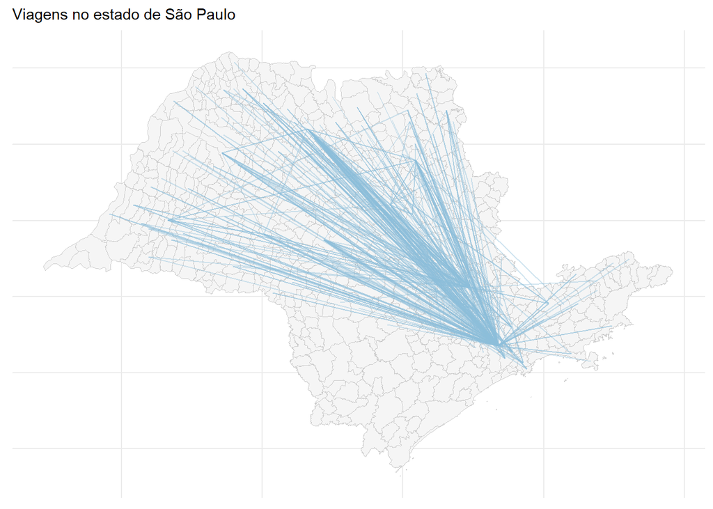

```r
no_axis <- theme(axis.title=element_blank(),
                 axis.text=element_blank(),
                 axis.ticks=element_blank())

ggplot() +
  geom_sf(data=all_muni_sp, fill="#F5F5F5", color="#CCCCCC", size=.15, show.legend = FALSE) +
  geom_sf(data = travel_network$geometry, color=alpha("#8BBDD9", 0.4)) +
  labs(subtitle="Viagens no estado de São Paulo", size=8) +
  theme_minimal() +
  no_axis
```

# 3 Construção do modelo gravitacional

O passo seguinte é a construção de um modelo gravitacional que estime as viagens entre duas localidades.

A equação clássica do modelo gravitacional é dada por:

$$T_{ij} = k V_i^\mu W_j^\alpha d_{ij}^{-\beta}$$

onde: $T_{ij}$ é o fluxo entre a origem e o destino; $V_i$ é a “emissibilidade” da origem - uma medida que indica o quanto as pessoas de lá saem. O que leva a ir; $W_j$ é a “atratividade” do destino - uma medida que indica o quanto as pessoas chegam. O que leva a vir; $d_{ij}$ é a resistência ao fluxo - como a distância; k é a constante de proporcionalidade; $\mu$, $\alpha$ e $\beta$ são os parâmetros do modelo.

Cenário de exemplo: viagens entre os bairros de uma cidade.

- Exemplo de $V_i$: população. Pode-se argumentar que, quanto mais gente em um bairro, maior o fluxo de saída.
- Exemplo de $W_j$: postos de trabalho. Pode-se argumentar que, quanto mais postos de trabalho em um bairro, mais pessoas fariam o traslado diariamente em direção ao bairro.

A fazer:

- Pegar os dados de população do IBGE e consolidar com a matriz OD;
- Selecionar possíveis candidatos para $V_i$. Renda? População?
- Selecionar possíveis candidatos para $W_j$. PIB?
- Avaliar dados socioeconômicos disponíveis em http://atlasbrasil.org.br/2013/pt/consulta/.

# 4 Conclusão